# CS 422: Homework #1

Tiffany Wong, Illinois Institute of Technology

### Part 1-A

```r
# import dplyr package
# install.packages("dplyr")
library("dplyr")
```

```r
# read in the college.csv into a dataframe
df <- read.csv("/Users/tiffwong/Desktop/cs422/hw/hw 1/College.csv")

# take rows 0 to 5 and then columns 1,5,8,10 from the df
print.data.frame(df[0:5, c(1, 5, 8, 10)])
```

```
                          Name Enroll F.Undergrad Outstate
1 Abilene Christian University    721        2885     7440
2           Adelphi University    512        2683    12280
3               Adrian College    336        1036    11250
4          Agnes Scott College    137         510    12960
5    Alaska Pacific University     55         249     7560
```

### Part 1-B

```r
# counts number of private colleges WITHOUT looping
private <- length(which(df$Private == "Yes"))

# counts number of public colleges WITHOUT looping
public <- length(which(df$Private == "No"))

#print answer statement
cat("There are", private, "private colleges, and", public, "public colleges in the dataset.")
```

```
There are 565 private colleges, and 212 public colleges in the dataset.
```

### Part 1-C

```r
# create subset of df with the following columns: Private, Apps, Accept, Enroll, PhD, perc.alumni, S.F.Ratio, and Grad.Rate
new_df <- df %>% select(Name, Private, Apps, Accept, Enroll, PhD, perc.alumni, S.F.Ratio, Grad.Rate)
new_df
```

| Name | Private | Apps | Accept | Enroll | PhD | perc.alumni | S.F.Ratio | Grad.Rate |
| --- | --- | --- | --- | --- | --- | --- | --- | --- |
| Abilene Christian University | Yes | 1660 | 1232 | 721 | 70 | 12 | 18.1 | 60 |
| Adelphi University | Yes | 2186 | 1924 | 512 | 29 | 16 | 12.2 | 56 |
| Adrian College | Yes | 1428 | 1097 | 336 | 53 | 30 | 12.9 | 54 |
| Agnes Scott College | Yes | 417 | 349 | 137 | 92 | 37 | 7.7 | 59 |
| Alaska Pacific University | Yes | 193 | 146 | 55 | 76 | 2 | 11.9 | 15 |
| Albertson College | Yes | 587 | 479 | 158 | 67 | 11 | 9.4 | 55 |
| Albertus Magnus College | Yes | 353 | 340 | 103 | 90 | 26 | 11.5 | 63 |
| Albion College | Yes | 1899 | 1720 | 489 | 89 | 37 | 13.7 | 73 |
| Albright College | Yes | 1038 | 839 | 227 | 79 | 23 | 11.3 | 80 |
| Alderson-Broaddus College | Yes | 582 | 498 | 172 | 40 | 15 | 11.5 | 52 |

[output cut: 767 more lines]

```r
NA
```

### Part 1-D(i) + (iii) extra credit

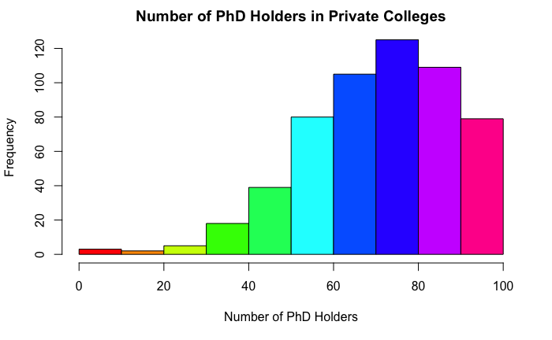

```r
# subset the df by private colleges first
private_df <- new_df[(new_df$Private == 'Yes'), ]

# create a vector for the number of bins in the histogram for private phd holders
colors = rainbow(10)

# histogram of PhD holders in private colleges
hist(private_df$PhD, main='Number of PhD Holders in Private Colleges',
     xlab='Number of PhD Holders', col=colors)
```

### Part 1-D(ii) + (iii) extra credit

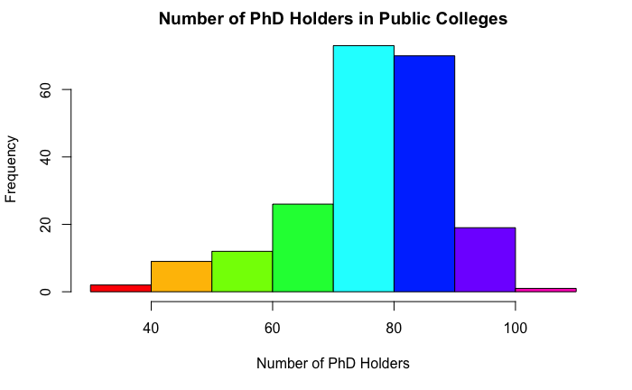

```r
# subset the df by private colleges first
public_df <- new_df[(new_df$Private == 'No'), ]

# create a vector for the number of bins in the histogram for public phd holders
colors = rainbow(8)

# histogram of PhD holders in public colleges
hist(public_df$PhD, main='Number of PhD Holders in Public Colleges',
     xlab='Number of PhD Holders', col=colors)
```

### Part 1-E(i)

```r
# order the dataframe in ascending order to get the lowest to highest grad rate
ascending_order <- new_df[order(new_df$Grad.Rate), ]

print.data.frame(ascending_order[1:5, c('Name', 'Grad.Rate')])
```

```
                         Name Grad.Rate
586 Texas Southern University        10
5   Alaska Pacific University        15
385 Montreat-Anderson College        15
67     Brewton-Parker College        18
114           Claflin College        21
```

### Part 1-E(ii)

```r
# order the dataframe in descending order to get the highest to lowest grad rate
descending_order <- new_df[order(-new_df$Grad.Rate), ]

print.data.frame(descending_order[1:5, c('Name', 'Grad.Rate')])
```

```
                           Name Grad.Rate
96            Cazenovia College       118
17              Amherst College       100
127 College of Mount St. Joseph       100
239          Grove City College       100
251          Harvard University       100
```

### Part 1-F

```r
# install.packages("psych")
library(psych)
```

### Part 1-I(i)

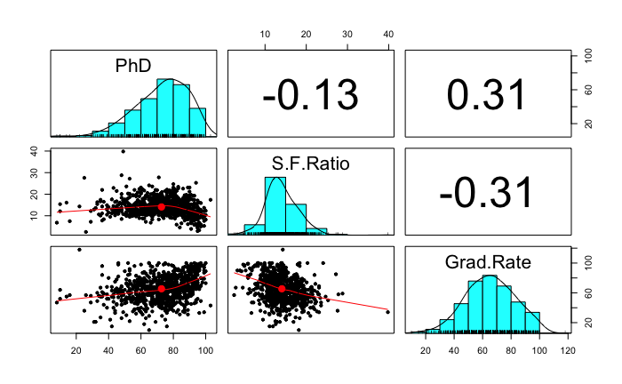

```r
# using on pairs.panels() to create correlation plot with three columns: phd, s.f.ratio, grad rate
pairs.panels(new_df[ , c('PhD', 'S.F.Ratio', 'Grad.Rate')])
```

### Part 1-I(ii)

Which two attributes have the highest correlation? Explain the reason behind this positive correlation (i.e., does this correlation make sense? Why?).

The two attributes with the highest correlation is Grad.Rate and PhD, meaning there is a high correlation between the graduation rate of a college with the number of PhD holders in said school. This makes sense to me because it’s possible that a lot of colleges have a pipeline where students who graduated from their undergrad program go straight into their Masters/PhD programs. So that would make sense why the higher the graduation rate is, the more PhD holders in the school.

### Part 1-I(iii)

Which two attributes exhibit the lowest correlation? Explain the reason behind this negative correlation (i.e., does this correlation make sense? Why?).

The two attributes with the lowest correlation is Grad.Rate and S.F.Ratio, meaning there is a high correlation between the graduation rate of a college with the student to faculty ratio in said school. This correlation could be higher in order for it to make sense to me because I think having a lower student to professor ratio (meaning there aren’t that many students in a class with one professor), could be beneficial to helping a student guarantee graduation. However, the variable is labeled student to faculty, meaning it could be including staff members whose job isn’t to help the students academically. All in all, I think it makes sense that the two variables have the lowest correlation because I personally won’t attribute a college’s graduation rate to its student to faculty ratio.

### Part 1-G

Which alumni donate more to their colleges — those who go to public schools or those who go to private schools?

As I found out from the boxplot visual below, alumni donate more to their college if they went to to a private school.

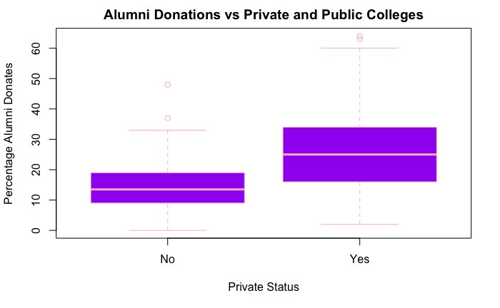

```r
# using private_df, public_df, and boxplot(), answer the following question with boxplots to compare:
# Which alumni donate more to their colleges --- those who go to public schools or those who go to private schools?

boxplot(perc.alumni~Private, data=df, main='Alumni Donations vs Private and Public Colleges', xlab='Private Status', ylab='Percentage Alumni Donates', col='purple', border='pink')
```

### Part 1-H(iii)

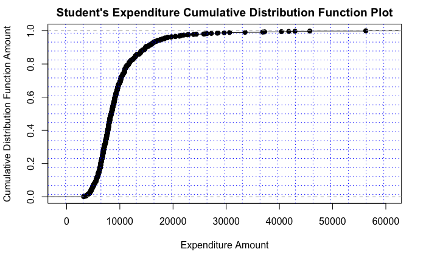

```r
plot(ecdf(df$Expend), main="Student's Expenditure Cumulative Distribution Function Plot", xlab='Expenditure Amount', ylab='Cumulative Distribution Function Amount')
grid(nx=20, ny=20, col='blue')
```